```python
# EDA와 데이터 전처리에 쓸 패키지
import pandas as pd
import numpy as np
import matplotlib.pyplot as plt
import seaborn as sns
import warnings
import os
import datetime as dt
import cufflinks as cf
import folium
from folium.plugins import HeatMap, MarkerCluster
from IPython.display import Image
import time
from shapely.geometry import Point, Polygon
import geopandas as gpd

# 예측 모델 생성에 쓸 패키지
from sklearn.model_selection import train_test_split
from sklearn.metrics import accuracy_score
import xgboost as xgb
import lightgbm as lgb
import catboost as cb
from sklearn.metrics import mean_squared_error, r2_score
from math import sqrt
import random
from sklearn.model_selection import KFold
from sklearn.model_selection import GridSearchCV, cross_val_score
from sklearn.decomposition import PCA
from sklearn.ensemble import RandomForestRegressor

plt.style.use('ggplot')
cf.go_offline()
warnings.filterwarnings('ignore')
%config InlineBackend.figure_format = 'retina'

import matplotlib.font_manager as fm
fm.get_fontconfig_fonts()
# font_location = '/usr/share/fonts/truetype/nanum/NanumGothicOTF.ttf'
font_location = 'C:/Windows/Fonts/NanumGothic.ttf' # For Windows
font_name = fm.FontProperties(fname=font_location).get_name()
plt.rc('font', family=font_name)

%matplotlib inline
```

```python
test = pd.read_csv('./data/test.csv', encoding='utf-8', parse_dates=['date'])
train = pd.read_csv('./data/train.csv', encoding='utf-8', parse_dates=['date'])
```

# 1. Train data EDA

- Train data 크기 : 415423행 * 21열
- Train data 컬럼 : 'id', 'date', 'bus_route_id', 'in_out', 'station_code', 'station_name', 'latitude', 'longitude', '6_7ride', '7_8_ride', '8_9_ride', '9_10_ride', '10_11_ride', '11_12_ride', '6_7_takeoff', '7_8_takeoff', '8_9_takeoff', '9_10_takeoff', '10_11_takeoff', '11_12_takeoff', '18_20_ride'
- null값은 없음
- 승하차 데이터를 기준으로 상관관계를 따져보면 18 ~ 20시 승차는 11~12시 승차와 가장 상관관계가 큼
- 승하차는 요일별로 어느 정도 차이가 존재(특히 월화수목, 금, 토일로 나뉘는 듯)
- 기상요인에 따라 크게 영향을 받는데(9월 22일이 그러함)
- 추석 같은 공휴일 고려 필요 > 10월 3일 개천절, 10월 9일 한글날
- 시외가 확실히 승하차량 총합은 적으나 평균값은 큼(max는 또 시내가 큼)
- 18~20시 탑승은 확실히 제주시와 서귀포시 시내에서 다량 발생(그러나 이게 정류장이 많아서 그런거지 또 따지고보면 개별 정류장은 크게 차이 없는 듯)
- 제주시내(공항, 대학교 등)와 애월 등에서 18~20시 탑승 다량 발생

[figure not shown]

```python
train.head()
```

|  | id | date | bus_route_id | in_out | station_code | station_name | latitude | longitude | 6~7_ride | 7~8_ride | ... | 9~10_ride | 10~11_ride | 11~12_ride | 6~7_takeoff | 7~8_takeoff | 8~9_takeoff | 9~10_takeoff | 10~11_takeoff | 11~12_takeoff | 18~20_ride |
| --- | --- | --- | --- | --- | --- | --- | --- | --- | --- | --- | --- | --- | --- | --- | --- | --- | --- | --- | --- | --- | --- |
| 0 | 0 | 2019-09-01 | 4270000 | 시외 | 344 | 제주썬호텔 | 33.48990 | 126.49373 | 0.0 | 1.0 | ... | 5.0 | 2.0 | 6.0 | 0.0 | 0.0 | 0.0 | 0.0 | 0.0 | 0.0 | 0.0 |
| 1 | 1 | 2019-09-01 | 4270000 | 시외 | 357 | 한라병원 | 33.48944 | 126.48508 | 1.0 | 4.0 | ... | 2.0 | 5.0 | 6.0 | 0.0 | 0.0 | 0.0 | 0.0 | 0.0 | 0.0 | 5.0 |
| 2 | 2 | 2019-09-01 | 4270000 | 시외 | 432 | 정존마을 | 33.48181 | 126.47352 | 1.0 | 1.0 | ... | 2.0 | 0.0 | 0.0 | 0.0 | 0.0 | 0.0 | 0.0 | 0.0 | 0.0 | 2.0 |
| 3 | 3 | 2019-09-01 | 4270000 | 시내 | 1579 | 제주국제공항(600번) | 33.50577 | 126.49252 | 0.0 | 17.0 | ... | 26.0 | 14.0 | 16.0 | 0.0 | 0.0 | 0.0 | 0.0 | 0.0 | 0.0 | 53.0 |
| 4 | 4 | 2019-09-01 | 4270000 | 시내 | 1646 | 중문관광단지입구 | 33.25579 | 126.41260 | 0.0 | 0.0 | ... | 0.0 | 0.0 | 0.0 | 0.0 | 0.0 | 0.0 | 1.0 | 0.0 | 0.0 | 0.0 |

5 rows × 21 columns

```python
train.shape
```

```
(415423, 21)
```

```python
train.info()
```

```
<class 'pandas.core.frame.DataFrame'>
RangeIndex: 415423 entries, 0 to 415422
Data columns (total 21 columns):
id               415423 non-null int64
date             415423 non-null datetime64[ns]
bus_route_id     415423 non-null int64
in_out           415423 non-null object
station_code     415423 non-null int64
station_name     415423 non-null object
latitude         415423 non-null float64
longitude        415423 non-null float64
6~7_ride         415423 non-null float64
7~8_ride         415423 non-null float64
8~9_ride         415423 non-null float64
9~10_ride        415423 non-null float64
10~11_ride       415423 non-null float64
11~12_ride       415423 non-null float64
6~7_takeoff      415423 non-null float64
7~8_takeoff      415423 non-null float64
8~9_takeoff      415423 non-null float64
9~10_takeoff     415423 non-null float64
10~11_takeoff    415423 non-null float64
11~12_takeoff    415423 non-null float64
18~20_ride       415423 non-null float64
dtypes: datetime64[ns](1), float64(15), int64(3), object(2)
memory usage: 66.6+ MB
```

```python
train.isnull().sum()
```

```
id               0
date             0
bus_route_id     0
in_out           0
station_code     0
station_name     0
latitude         0
longitude        0
6~7_ride         0
7~8_ride         0
8~9_ride         0
9~10_ride        0
10~11_ride       0
11~12_ride       0
6~7_takeoff      0
7~8_takeoff      0
8~9_takeoff      0
9~10_takeoff     0
10~11_takeoff    0
11~12_takeoff    0
18~20_ride       0
dtype: int64
```

```python
train.describe()
```

|  | id | bus_route_id | station_code | latitude | longitude | 6~7_ride | 7~8_ride | 8~9_ride | 9~10_ride | 10~11_ride | 11~12_ride | 6~7_takeoff | 7~8_takeoff | 8~9_takeoff | 9~10_takeoff | 10~11_takeoff | 11~12_takeoff | 18~20_ride |
| --- | --- | --- | --- | --- | --- | --- | --- | --- | --- | --- | --- | --- | --- | --- | --- | --- | --- | --- |
| count | 415423.000000 | 4.154230e+05 | 4.154230e+05 | 415423.000000 | 415423.000000 | 415423.000000 | 415423.000000 | 415423.000000 | 415423.000000 | 415423.000000 | 415423.000000 | 415423.000000 | 415423.000000 | 415423.000000 | 415423.000000 | 415423.000000 | 415423.000000 | 415423.000000 |
| mean | 207711.000000 | 2.691935e+07 | 4.209311e+04 | 33.420375 | 126.533574 | 0.305893 | 0.829699 | 0.815350 | 0.642475 | 0.599618 | 0.579393 | 0.112870 | 0.344870 | 0.516481 | 0.430922 | 0.408001 | 0.402874 | 1.242095 |
| std | 119922.434776 | 3.924652e+06 | 4.971504e+05 | 0.107996 | 0.140986 | 1.109766 | 2.255116 | 2.317561 | 1.959844 | 1.885941 | 1.942137 | 0.597714 | 1.279179 | 1.658850 | 1.485124 | 1.412839 | 1.446080 | 4.722287 |
| min | 0.000000 | 4.270000e+06 | 1.000000e+00 | 33.208350 | 126.165040 | 0.000000 | 0.000000 | 0.000000 | 0.000000 | 0.000000 | 0.000000 | 0.000000 | 0.000000 | 0.000000 | 0.000000 | 0.000000 | 0.000000 | 0.000000 |
| 25% | 103855.500000 | 2.346000e+07 | 3.200000e+02 | 33.291080 | 126.475780 | 0.000000 | 0.000000 | 0.000000 | 0.000000 | 0.000000 | 0.000000 | 0.000000 | 0.000000 | 0.000000 | 0.000000 | 0.000000 | 0.000000 | 0.000000 |
| 50% | 207711.000000 | 2.803000e+07 | 1.130000e+03 | 33.478850 | 126.529770 | 0.000000 | 0.000000 | 0.000000 | 0.000000 | 0.000000 | 0.000000 | 0.000000 | 0.000000 | 0.000000 | 0.000000 | 0.000000 | 0.000000 | 0.000000 |
| 75% | 311566.500000 | 3.003000e+07 | 2.226000e+03 | 33.500020 | 126.575890 | 0.000000 | 1.000000 | 1.000000 | 1.000000 | 0.000000 | 0.000000 | 0.000000 | 0.000000 | 0.000000 | 0.000000 | 0.000000 | 0.000000 | 1.000000 |
| max | 415422.000000 | 3.282000e+07 | 6.115101e+06 | 33.963640 | 126.965670 | 85.000000 | 94.000000 | 136.000000 | 78.000000 | 124.000000 | 99.000000 | 45.000000 | 66.000000 | 59.000000 | 65.000000 | 52.000000 | 81.000000 | 272.000000 |

```python
ride_columns = ['6~7_ride', '7~8_ride', '8~9_ride', '9~10_ride', '10~11_ride', '11~12_ride',
               '6~7_takeoff', '7~8_takeoff', '8~9_takeoff', '9~10_takeoff', '10~11_takeoff', '11~12_takeoff',
               '18~20_ride']
```

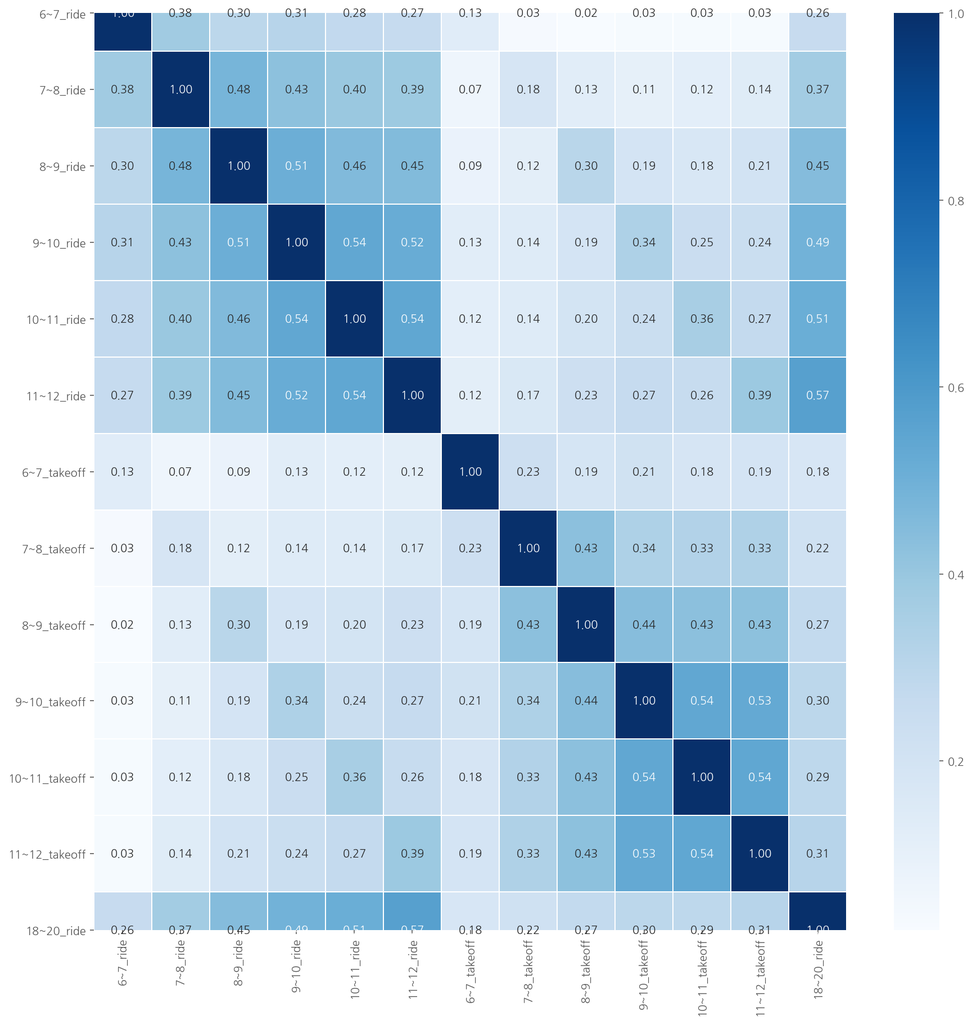

```python
plt.figure(figsize=(15, 15))
sns.heatmap(data=train[ride_columns].corr(), annot=True, fmt='.2f',
           linewidths=.5, cmap='Blues')
```

```python
train['요일'] = train['date'].dt.dayofweek
dow = {0:'Mon', 1:'Tue', 2:'Wed', 3:'Thu', 4:'Fri', 5:'Sat', 6:'Sun'}
train['요일'] = train['요일'].apply(lambda x: dow[x])
train.head()
```

|  | id | date | bus_route_id | in_out | station_code | station_name | latitude | longitude | 6~7_ride | 7~8_ride | ... | 10~11_ride | 11~12_ride | 6~7_takeoff | 7~8_takeoff | 8~9_takeoff | 9~10_takeoff | 10~11_takeoff | 11~12_takeoff | 18~20_ride | 요일 |
| --- | --- | --- | --- | --- | --- | --- | --- | --- | --- | --- | --- | --- | --- | --- | --- | --- | --- | --- | --- | --- | --- |
| 0 | 0 | 2019-09-01 | 4270000 | 시외 | 344 | 제주썬호텔 | 33.48990 | 126.49373 | 0.0 | 1.0 | ... | 2.0 | 6.0 | 0.0 | 0.0 | 0.0 | 0.0 | 0.0 | 0.0 | 0.0 | Sun |
| 1 | 1 | 2019-09-01 | 4270000 | 시외 | 357 | 한라병원 | 33.48944 | 126.48508 | 1.0 | 4.0 | ... | 5.0 | 6.0 | 0.0 | 0.0 | 0.0 | 0.0 | 0.0 | 0.0 | 5.0 | Sun |
| 2 | 2 | 2019-09-01 | 4270000 | 시외 | 432 | 정존마을 | 33.48181 | 126.47352 | 1.0 | 1.0 | ... | 0.0 | 0.0 | 0.0 | 0.0 | 0.0 | 0.0 | 0.0 | 0.0 | 2.0 | Sun |
| 3 | 3 | 2019-09-01 | 4270000 | 시내 | 1579 | 제주국제공항(600번) | 33.50577 | 126.49252 | 0.0 | 17.0 | ... | 14.0 | 16.0 | 0.0 | 0.0 | 0.0 | 0.0 | 0.0 | 0.0 | 53.0 | Sun |
| 4 | 4 | 2019-09-01 | 4270000 | 시내 | 1646 | 중문관광단지입구 | 33.25579 | 126.41260 | 0.0 | 0.0 | ... | 0.0 | 0.0 | 0.0 | 0.0 | 0.0 | 1.0 | 0.0 | 0.0 | 0.0 | Sun |

5 rows × 22 columns

## 일별 오전 승하차 비교

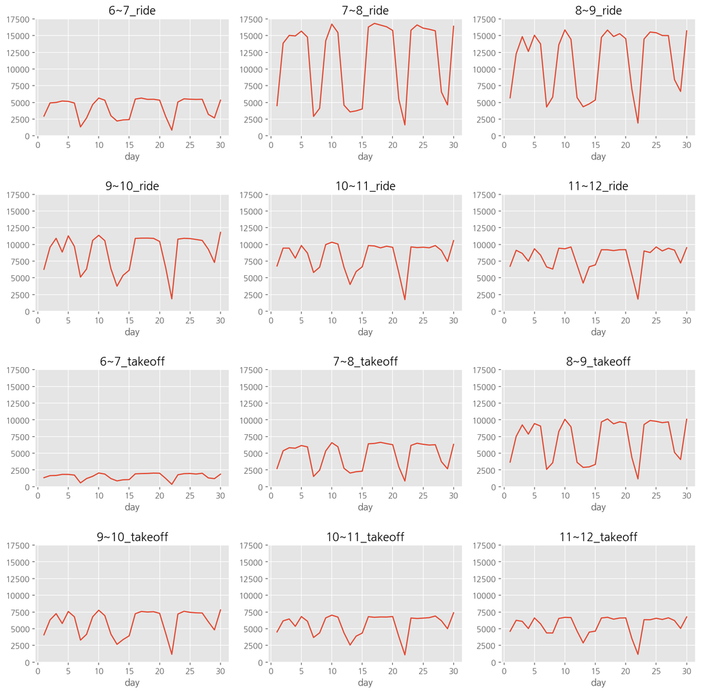

```python
date_groupby = train.groupby(by='date').sum()[ride_columns].reset_index()
date_groupby['day'] = date_groupby['date'].dt.day
temp = np.array(ride_columns[:-1]).reshape(4,3)

fig, ax = plt.subplots(4, 3, figsize=(15, 15))
plt.subplots_adjust(hspace=0.5, wspace=0.2)
for i in range(4):
    for j in range(3):
        g = sns.lineplot(data = date_groupby, x='day', y=date_groupby[temp[i, j]], ax=ax[i, j])
        g.set_title(temp[i,j])
        g.set_ylabel('')
        g.set_ylim((0, 17500))
        # g.set_xticklabels(g.get_xticklabels(), rotation=45)

plt.show()
```

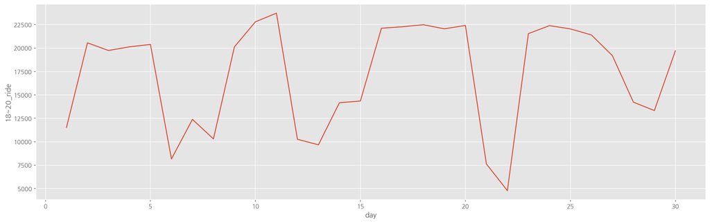

```python
plt.figure(figsize=(20,6))
sns.lineplot(data=date_groupby, x='day', y='18~20_ride')
plt.show()
```

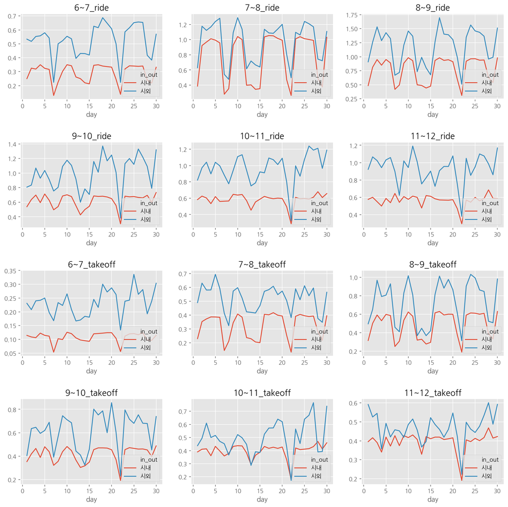

```python
inout_groupby = train.groupby(by=['in_out','date']).mean()[ride_columns].reset_index()
inout_groupby['day'] = inout_groupby['date'].dt.day

fig, ax = plt.subplots(4, 3, figsize=(15, 15))
plt.subplots_adjust(hspace=0.5, wspace=0.2)

for i in range(4):
    for j in range(3):
        g = sns.lineplot(data = inout_groupby, x='day', y=inout_groupby[temp[i, j]], ax=ax[i, j], hue='in_out')
        g.set_title(temp[i,j])
        g.set_ylabel('')
        g.legend(loc='lower right')
        # g.set_ylim((0, 17500))
        # g.set_xticklabels(g.get_xticklabels(), rotation=45)


plt.show()
```

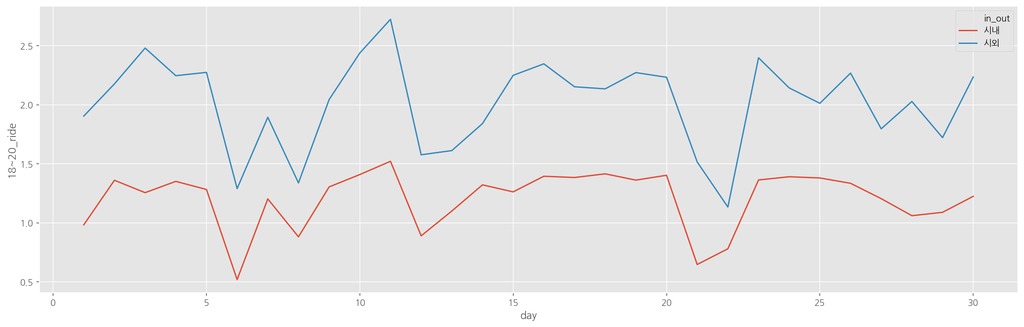

```python
plt.figure(figsize=(20,6))
sns.lineplot(data=inout_groupby, x='day', y='18~20_ride', hue='in_out')
plt.show()
```

## 요일별 오전 승하차 비교

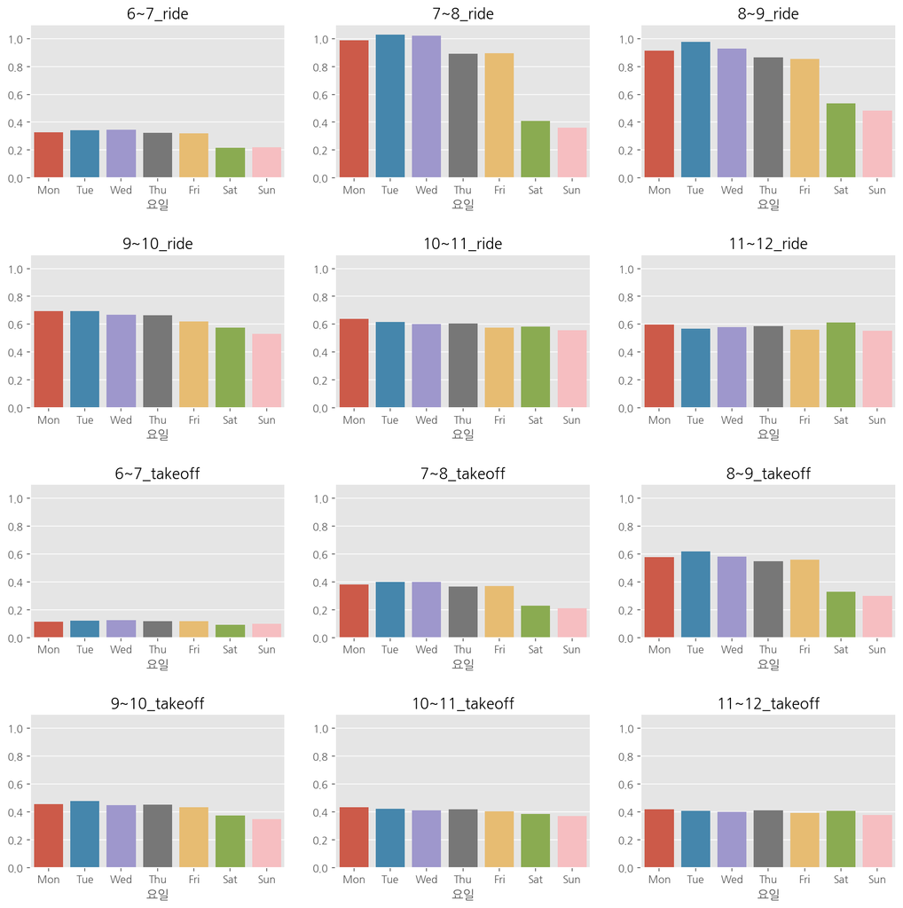

```python
dow_groupby = train.groupby(by='요일').mean()[ride_columns].reset_index()

fig, ax = plt.subplots(4, 3, figsize=(15, 15))
plt.subplots_adjust(hspace=0.5, wspace=0.2)
for i in range(4):
    for j in range(3):
        g = sns.barplot(data = dow_groupby, x='요일', y=dow_groupby[temp[i, j]], ax=ax[i, j],
                       order=list(dow.values()))
        g.set_title(temp[i,j])
        g.set_ylabel('')
        g.set_ylim((0, 1.1))
        # g.set_xticklabels(g.get_xticklabels(), rotation=45)

plt.show()
```

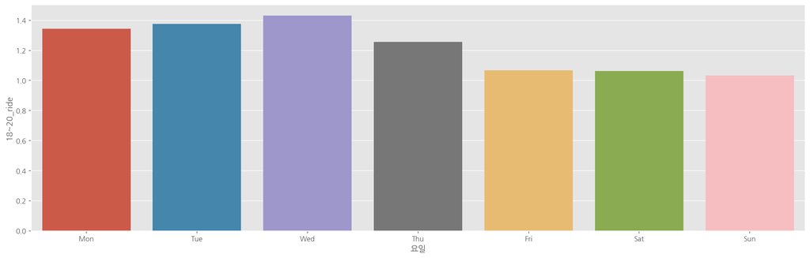

```python
plt.figure(figsize=(20,6))
sns.barplot(data=dow_groupby, x='요일', y='18~20_ride', order=list(dow.values()))
plt.show()
```

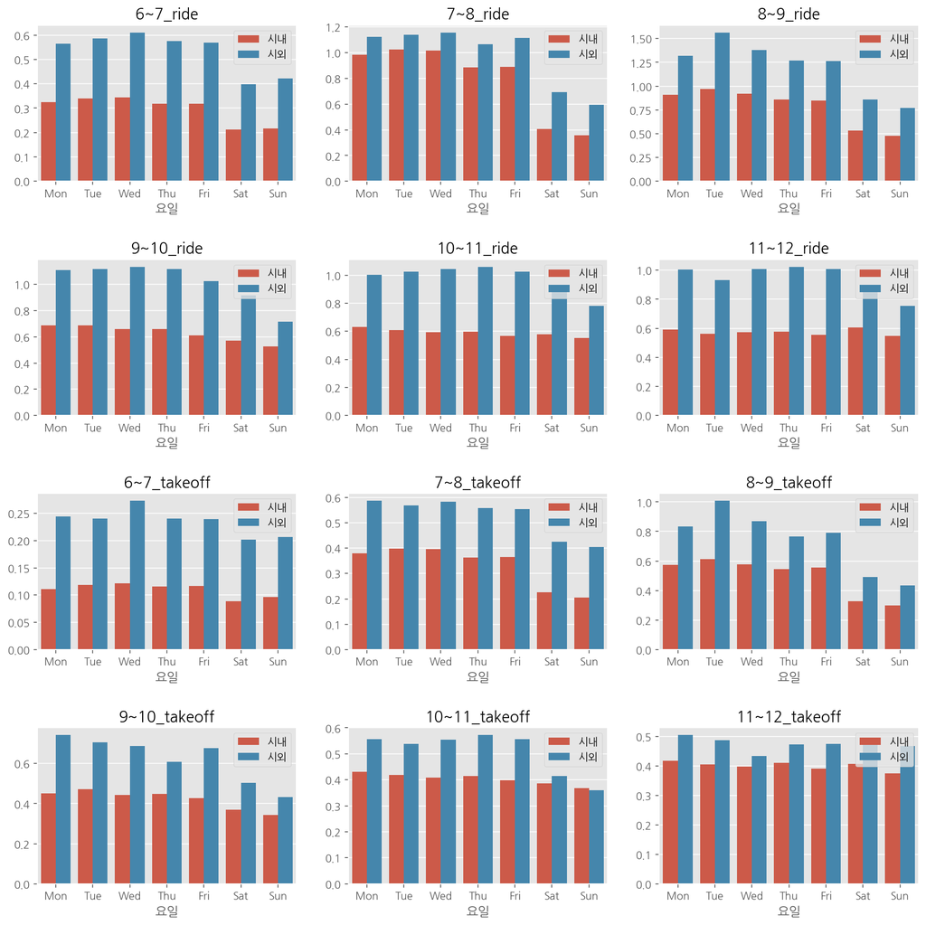

```python
inout_groupby2 = train.groupby(by=['in_out','요일']).mean()[ride_columns].reset_index()

fig, ax = plt.subplots(4, 3, figsize=(15, 15))
plt.subplots_adjust(hspace=0.5, wspace=0.2)

for i in range(4):
    for j in range(3):
        g = sns.barplot(data = inout_groupby2, x='요일', y=inout_groupby2[temp[i, j]], ax=ax[i, j], hue='in_out',
                        order=list(dow.values()))
        g.set_title(temp[i,j])
        g.set_ylabel('')
        g.legend(loc='upper right')
        # g.set_ylim((0, 17500))
        # g.set_xticklabels(g.get_xticklabels(), rotation=45)


plt.show()
```

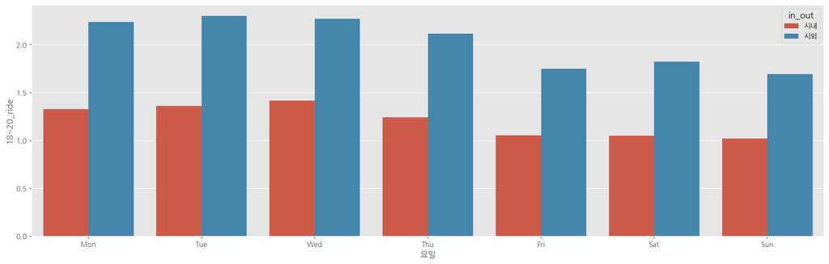

```python
plt.figure(figsize=(20,6))
sns.barplot(data=inout_groupby2, x='요일', y='18~20_ride', hue='in_out', order=list(dow.values()))
plt.show()
```

## 지역별 승하차 비교

```python
print('- 정류장 이름 기준 고유값 개수 :', len(train['station_name'].unique()))
print('- 위경도 기준 고유값 개수 :', len(train[['latitude','longitude']].drop_duplicates()))
```

```
- 정류장 이름 기준 고유값 개수 : 1961
- 위경도 기준 고유값 개수 : 3563
```

```python
loc_groupby = train.groupby(['latitude','longitude','station_name']).mean()[ride_columns].reset_index()
loc_groupby.head()
```

|  | latitude | longitude | station_name | 6~7_ride | 7~8_ride | 8~9_ride | 9~10_ride | 10~11_ride | 11~12_ride | 6~7_takeoff | 7~8_takeoff | 8~9_takeoff | 9~10_takeoff | 10~11_takeoff | 11~12_takeoff | 18~20_ride |
| --- | --- | --- | --- | --- | --- | --- | --- | --- | --- | --- | --- | --- | --- | --- | --- | --- |
| 0 | 33.20835 | 126.29012 | 산이수동 | 0.000000 | 0.000000 | 0.023810 | 0.023810 | 0.023810 | 0.238095 | 0.000000 | 0.214286 | 1.023810 | 0.547619 | 0.261905 | 0.547619 | 0.142857 |
| 1 | 33.20847 | 126.29025 | 산이수동 | 0.000000 | 0.500000 | 0.227273 | 0.022727 | 0.045455 | 0.113636 | 0.000000 | 0.022727 | 0.000000 | 0.318182 | 0.250000 | 0.500000 | 0.022727 |
| 2 | 33.21097 | 126.25733 | 모슬포남항여객선터미널(운진항) | 0.043478 | 0.291925 | 0.245342 | 0.055901 | 0.226708 | 0.260870 | 0.012422 | 0.288820 | 0.574534 | 0.506211 | 0.661491 | 0.509317 | 0.102484 |
| 3 | 33.21119 | 126.25748 | 모슬포남항여객선터미널(운진항) | 0.785714 | 1.051948 | 0.883117 | 0.896104 | 0.720779 | 0.944805 | 0.016234 | 0.285714 | 0.288961 | 0.207792 | 0.113636 | 0.107143 | 1.058442 |
| 4 | 33.21201 | 126.29237 | 송악펜션단지 | 0.000000 | 0.000000 | 0.000000 | 0.000000 | 0.153846 | 0.076923 | 0.000000 | 0.000000 | 0.153846 | 0.076923 | 0.230769 | 0.461538 | 0.153846 |

```python
m = folium.Map(location=[loc_groupby['latitude'].mean(), loc_groupby['longitude'].mean()],
             zoom_start=11)

# for lat, long, name in zip(merged2['latitude'], merged2['longitude'], merged2['station_name']):
#     folium.Marker([lat, long],
#                  popup=name).add_to(m)

MarkerCluster(loc_groupby[['latitude','longitude']]).add_to(m)

HeatMap(loc_groupby[['latitude','longitude', '18~20_ride']], radius=10).add_to(m)

m
```

[interactive chart not shown]

```python
train[train['in_out']=='시내'].describe()
```

|  | id | bus_route_id | station_code | latitude | longitude | 6~7_ride | 7~8_ride | 8~9_ride | 9~10_ride | 10~11_ride | 11~12_ride | 6~7_takeoff | 7~8_takeoff | 8~9_takeoff | 9~10_takeoff | 10~11_takeoff | 11~12_takeoff | 18~20_ride |
| --- | --- | --- | --- | --- | --- | --- | --- | --- | --- | --- | --- | --- | --- | --- | --- | --- | --- | --- |
| count | 408500.000000 | 4.085000e+05 | 4.085000e+05 | 408500.000000 | 408500.000000 | 408500.000000 | 408500.000000 | 408500.000000 | 408500.000000 | 408500.000000 | 408500.000000 | 408500.000000 | 408500.000000 | 408500.000000 | 408500.000000 | 408500.000000 | 408500.000000 | 408500.000000 |
| mean | 207749.525084 | 2.697133e+07 | 3.602391e+04 | 33.420248 | 126.534783 | 0.301983 | 0.826859 | 0.808524 | 0.635988 | 0.593119 | 0.573163 | 0.110776 | 0.341726 | 0.512468 | 0.427537 | 0.406252 | 0.401660 | 1.228499 |
| std | 119931.086832 | 3.790631e+06 | 4.587764e+05 | 0.106642 | 0.141548 | 1.098561 | 2.253217 | 2.305378 | 1.946543 | 1.873274 | 1.934327 | 0.591870 | 1.272409 | 1.645697 | 1.476637 | 1.409321 | 1.446042 | 4.726250 |
| min | 3.000000 | 4.270000e+06 | 1.000000e+00 | 33.208350 | 126.165040 | 0.000000 | 0.000000 | 0.000000 | 0.000000 | 0.000000 | 0.000000 | 0.000000 | 0.000000 | 0.000000 | 0.000000 | 0.000000 | 0.000000 | 0.000000 |
| 25% | 103874.750000 | 2.347000e+07 | 3.160000e+02 | 33.292817 | 126.476700 | 0.000000 | 0.000000 | 0.000000 | 0.000000 | 0.000000 | 0.000000 | 0.000000 | 0.000000 | 0.000000 | 0.000000 | 0.000000 | 0.000000 | 0.000000 |
| 50% | 207782.500000 | 2.808000e+07 | 1.133000e+03 | 33.478640 | 126.531370 | 0.000000 | 0.000000 | 0.000000 | 0.000000 | 0.000000 | 0.000000 | 0.000000 | 0.000000 | 0.000000 | 0.000000 | 0.000000 | 0.000000 | 0.000000 |
| 75% | 311667.250000 | 3.003000e+07 | 2.234000e+03 | 33.500050 | 126.576730 | 0.000000 | 1.000000 | 1.000000 | 1.000000 | 0.000000 | 0.000000 | 0.000000 | 0.000000 | 0.000000 | 0.000000 | 0.000000 | 0.000000 | 1.000000 |
| max | 415422.000000 | 3.282000e+07 | 6.115101e+06 | 33.556170 | 126.935190 | 85.000000 | 94.000000 | 136.000000 | 78.000000 | 124.000000 | 99.000000 | 45.000000 | 66.000000 | 59.000000 | 65.000000 | 52.000000 | 81.000000 | 272.000000 |

```python
train[train['in_out']=='시외'].describe()
```

|  | id | bus_route_id | station_code | latitude | longitude | 6~7_ride | 7~8_ride | 8~9_ride | 9~10_ride | 10~11_ride | 11~12_ride | 6~7_takeoff | 7~8_takeoff | 8~9_takeoff | 9~10_takeoff | 10~11_takeoff | 11~12_takeoff | 18~20_ride |
| --- | --- | --- | --- | --- | --- | --- | --- | --- | --- | --- | --- | --- | --- | --- | --- | --- | --- | --- |
| count | 6923.000000 | 6.923000e+03 | 6.923000e+03 | 6923.000000 | 6923.000000 | 6923.000000 | 6923.000000 | 6923.000000 | 6923.000000 | 6923.000000 | 6923.000000 | 6923.000000 | 6923.000000 | 6923.000000 | 6923.000000 | 6923.000000 | 6923.000000 | 6923.000000 |
| mean | 205437.780731 | 2.385221e+07 | 4.002136e+05 | 33.427856 | 126.462220 | 0.536617 | 0.997256 | 1.218114 | 1.025278 | 0.983100 | 0.946988 | 0.236458 | 0.530406 | 0.753286 | 0.630651 | 0.511195 | 0.474505 | 2.044345 |
| std | 119397.418378 | 8.176704e+06 | 1.510486e+06 | 0.169566 | 0.073018 | 1.624158 | 2.358597 | 2.920715 | 2.599774 | 2.493535 | 2.328471 | 0.867227 | 1.618941 | 2.293497 | 1.910167 | 1.603588 | 1.446646 | 4.408946 |
| min | 0.000000 | 4.270000e+06 | 3.430000e+02 | 33.235950 | 126.294110 | 0.000000 | 0.000000 | 0.000000 | 0.000000 | 0.000000 | 0.000000 | 0.000000 | 0.000000 | 0.000000 | 0.000000 | 0.000000 | 0.000000 | 0.000000 |
| 25% | 102830.500000 | 2.244000e+07 | 3.900000e+02 | 33.250180 | 126.424660 | 0.000000 | 0.000000 | 0.000000 | 0.000000 | 0.000000 | 0.000000 | 0.000000 | 0.000000 | 0.000000 | 0.000000 | 0.000000 | 0.000000 | 0.000000 |
| 50% | 202200.000000 | 2.435000e+07 | 4.320000e+02 | 33.489440 | 126.485080 | 0.000000 | 0.000000 | 0.000000 | 0.000000 | 0.000000 | 0.000000 | 0.000000 | 0.000000 | 0.000000 | 0.000000 | 0.000000 | 0.000000 | 0.000000 |
| 75% | 307704.500000 | 3.018000e+07 | 2.014000e+03 | 33.489900 | 126.488530 | 0.000000 | 1.000000 | 1.000000 | 1.000000 | 1.000000 | 1.000000 | 0.000000 | 0.000000 | 1.000000 | 0.000000 | 0.000000 | 0.000000 | 2.000000 |
| max | 415225.000000 | 3.264000e+07 | 6.115059e+06 | 33.963640 | 126.965670 | 21.000000 | 29.000000 | 44.000000 | 36.000000 | 43.000000 | 41.000000 | 13.000000 | 23.000000 | 31.000000 | 29.000000 | 30.000000 | 31.000000 | 42.000000 |

```python
loc_groupby[['station_name', '18~20_ride']].iplot(kind='bar', x='station_name',y='18~20_ride', )
```

[interactive chart not shown]

# 2. BTS data EDA

- 06시 ~ 12시 까지의 데이터만 존재 > 크게 쓸모 없을 듯
- 역시나 제주시에서 많이 탑승하는 경향이 보임

```python
bus_bts = pd.read_csv('./data/bus_bts.csv', encoding='utf-8')
```

```python
bus_bts.columns
```

```
Index(['user_card_id', 'bus_route_id', 'vhc_id', 'geton_date', 'geton_time',
       'geton_station_code', 'geton_station_name', 'getoff_date',
       'getoff_time', 'getoff_station_code', 'getoff_station_name',
       'user_category', 'user_count'],
      dtype='object')
```

```python
bus_bts['geton'] = bus_bts['geton_date'] + ' ' + bus_bts['geton_time']
bus_bts['getoff'] = bus_bts['getoff_date'] + ' ' + bus_bts['getoff_time']

bus_bts['geton'] = pd.to_datetime(bus_bts['geton'])
bus_bts['getoff'] = pd.to_datetime(bus_bts['getoff'])
```

```python
bus_bts.head()
```

|  | user_card_id | bus_route_id | vhc_id | geton_date | geton_time | geton_station_code | geton_station_name | getoff_date | getoff_time | getoff_station_code | getoff_station_name | user_category | user_count | geton | getoff |
| --- | --- | --- | --- | --- | --- | --- | --- | --- | --- | --- | --- | --- | --- | --- | --- |
| 0 | 1.010010e+15 | 23000000 | 149793674 | 2019-09-10 | 06:34:45 | 360 | 노형오거리 | 2019-09-10 | 07:10:31 | 592.0 | 화북초등학교 | 1 | 1 | 2019-09-10 06:34:45 | 2019-09-10 07:10:31 |
| 1 | 1.010010e+15 | 23000000 | 149793674 | 2019-09-10 | 06:34:58 | 360 | 노형오거리 | 2019-09-10 | 06:56:27 | 3273.0 | 고산동산(광양방면) | 1 | 1 | 2019-09-10 06:34:58 | 2019-09-10 06:56:27 |
| 2 | 1.019160e+15 | 21420000 | 149793535 | 2019-09-10 | 07:19:07 | 2495 | 동광환승정류장4(제주방면) | 2019-09-10 | 07:40:29 | 431.0 | 정존마을 | 4 | 1 | 2019-09-10 07:19:07 | 2019-09-10 07:40:29 |
| 3 | 1.019150e+15 | 21420000 | 149793512 | 2019-09-09 | 09:14:47 | 3282 | 대정환승정류장(대정읍사무소) | 2019-09-09 | 10:02:46 | 431.0 | 정존마을 | 1 | 1 | 2019-09-09 09:14:47 | 2019-09-09 10:02:46 |
| 4 | 1.010010e+15 | 21420000 | 149793512 | 2019-09-09 | 09:28:53 | 2820 | 삼정지에듀 | 2019-09-09 | 10:21:37 | 2972.0 | 제주국제공항(종점) | 4 | 1 | 2019-09-09 09:28:53 | 2019-09-09 10:21:37 |

```python
bus_bts['탑승날짜'] = bus_bts['geton'].dt.day
bus_bts['탑승시간'] = bus_bts['geton'].dt.hour
bus_bts['탑승요일'] = bus_bts['geton'].dt.dayofweek.apply(lambda x: dow[x])
```

```python
bus_bts.head()
```

|  | user_card_id | bus_route_id | vhc_id | geton_date | geton_time | geton_station_code | geton_station_name | getoff_date | getoff_time | getoff_station_code | getoff_station_name | user_category | user_count | geton | getoff | 탑승날짜 | 탑승시간 | 탑승요일 |
| --- | --- | --- | --- | --- | --- | --- | --- | --- | --- | --- | --- | --- | --- | --- | --- | --- | --- | --- |
| 0 | 1.010010e+15 | 23000000 | 149793674 | 2019-09-10 | 06:34:45 | 360 | 노형오거리 | 2019-09-10 | 07:10:31 | 592.0 | 화북초등학교 | 1 | 1 | 2019-09-10 06:34:45 | 2019-09-10 07:10:31 | 10 | 6 | Tue |
| 1 | 1.010010e+15 | 23000000 | 149793674 | 2019-09-10 | 06:34:58 | 360 | 노형오거리 | 2019-09-10 | 06:56:27 | 3273.0 | 고산동산(광양방면) | 1 | 1 | 2019-09-10 06:34:58 | 2019-09-10 06:56:27 | 10 | 6 | Tue |
| 2 | 1.019160e+15 | 21420000 | 149793535 | 2019-09-10 | 07:19:07 | 2495 | 동광환승정류장4(제주방면) | 2019-09-10 | 07:40:29 | 431.0 | 정존마을 | 4 | 1 | 2019-09-10 07:19:07 | 2019-09-10 07:40:29 | 10 | 7 | Tue |
| 3 | 1.019150e+15 | 21420000 | 149793512 | 2019-09-09 | 09:14:47 | 3282 | 대정환승정류장(대정읍사무소) | 2019-09-09 | 10:02:46 | 431.0 | 정존마을 | 1 | 1 | 2019-09-09 09:14:47 | 2019-09-09 10:02:46 | 9 | 9 | Mon |
| 4 | 1.010010e+15 | 21420000 | 149793512 | 2019-09-09 | 09:28:53 | 2820 | 삼정지에듀 | 2019-09-09 | 10:21:37 | 2972.0 | 제주국제공항(종점) | 4 | 1 | 2019-09-09 09:28:53 | 2019-09-09 10:21:37 | 9 | 9 | Mon |

```python
geton11_groupby = bus_bts[bus_bts['탑승시간']==11].groupby(by=['geton_station_code', 'geton_station_name',
                                     'getoff_station_code','getoff_station_name']).count()['geton'].reset_index()
geton11_groupby.sort_values(by='geton', ascending=False).head(20)
```

|  | geton_station_code | geton_station_name | getoff_station_code | getoff_station_name | geton |
| --- | --- | --- | --- | --- | --- |
| 17337 | 447 | 제주고등학교/중흥S클래스 | 447.0 | 제주고등학교/중흥S클래스 | 1166 |
| 7110 | 200 | 제주대학교 | 200.0 | 제주대학교 | 546 |
| 44281 | 3271 | 제주시청(광양방면) | 283.0 | 중앙로(현대약국) | 520 |
| 9258 | 263 | 회천입구 | 263.0 | 회천입구 | 481 |
| 10947 | 284 | 중앙로(국민은행) | 3270.0 | 제주시청(아라방면) | 458 |
| 34155 | 1958 | 서귀북초등학교 | 1957.0 | 중앙로터리 | 370 |
| 12791 | 320 | 제주도청신제주로터리 | 638.0 | 제주국제공항(구제주방면) | 354 |
| 7304 | 201 | 제주대학교 | 3271.0 | 제주시청(광양방면) | 343 |
| 17150 | 443 | 제주한라대학교 | 443.0 | 제주한라대학교 | 341 |
| 44853 | 3275 | 제주지방법원(광양방면) | 3271.0 | 제주시청(광양방면) | 329 |
| 14445 | 358 | 한라병원 | 2970.0 | 제주시외버스터미널(종점) | 327 |
| 4912 | 149 | 제주버스터미널 | 3270.0 | 제주시청(아라방면) | 324 |
| 9517 | 270 | 보성시장 | 283.0 | 중앙로(현대약국) | 321 |
| 9589 | 271 | 광양 | 282.0 | 중앙로(동문시장) | 319 |
| 6822 | 192 | 함덕환승정류장(함덕해수욕장) | 2972.0 | 제주국제공항(종점) | 300 |
| 44199 | 3270 | 제주시청(아라방면) | 3274.0 | 제주지방법원(아라방면) | 282 |
| 44280 | 3271 | 제주시청(광양방면) | 282.0 | 중앙로(동문시장) | 275 |
| 44389 | 3271 | 제주시청(광양방면) | 2969.0 | 제주버스터미널(종점) | 268 |
| 26755 | 1355 | 제주국제공항(신제주방면) | 321.0 | 제주도청신제주로터리 | 260 |
| 10506 | 279 | 동문로터리(동문시장) | 1355.0 | 제주국제공항(신제주방면) | 259 |

```python
geton10_groupby = bus_bts[bus_bts['탑승시간']==10].groupby(by=['geton_station_code', 'geton_station_name',
                                     'getoff_station_code','getoff_station_name']).count()['geton'].reset_index()
geton10_groupby.sort_values(by='geton', ascending=False).head(20)
```

|  | geton_station_code | geton_station_name | getoff_station_code | getoff_station_name | geton |
| --- | --- | --- | --- | --- | --- |
| 17126 | 447 | 제주고등학교/중흥S클래스 | 447.0 | 제주고등학교/중흥S클래스 | 829 |
| 44036 | 3271 | 제주시청(광양방면) | 283.0 | 중앙로(현대약국) | 543 |
| 4974 | 149 | 제주버스터미널 | 2221.0 | 성산항 | 536 |
| 33863 | 1958 | 서귀북초등학교 | 1957.0 | 중앙로터리 | 505 |
| 12667 | 320 | 제주도청신제주로터리 | 638.0 | 제주국제공항(구제주방면) | 469 |
| 7111 | 200 | 제주대학교 | 200.0 | 제주대학교 | 387 |
| 44574 | 3275 | 제주지방법원(광양방면) | 3271.0 | 제주시청(광양방면) | 350 |
| 6844 | 192 | 함덕환승정류장(함덕해수욕장) | 2972.0 | 제주국제공항(종점) | 342 |
| 10803 | 284 | 중앙로(국민은행) | 3270.0 | 제주시청(아라방면) | 313 |
| 12047 | 311 | 제주여자상업고등학교 | 279.0 | 동문로터리(동문시장) | 301 |
| 4999 | 149 | 제주버스터미널 | 3270.0 | 제주시청(아라방면) | 298 |
| 14309 | 358 | 한라병원 | 2970.0 | 제주시외버스터미널(종점) | 298 |
| 44035 | 3271 | 제주시청(광양방면) | 282.0 | 중앙로(동문시장) | 280 |
| 13163 | 325 | 관덕정 | 1355.0 | 제주국제공항(신제주방면) | 272 |
| 40211 | 2617 | 성산환승정류장(고성리한국물류) | 2972.0 | 제주국제공항(종점) | 259 |
| 10370 | 279 | 동문로터리(동문시장) | 1355.0 | 제주국제공항(신제주방면) | 252 |
| 9504 | 271 | 광양 | 282.0 | 중앙로(동문시장) | 251 |
| 14583 | 360 | 노형오거리 | 2970.0 | 제주시외버스터미널(종점) | 240 |
| 22754 | 1013 | 세화환승정류장(세화리) | 2972.0 | 제주국제공항(종점) | 234 |
| 7292 | 201 | 제주대학교 | 3271.0 | 제주시청(광양방면) | 234 |

```python
geton9_groupby = bus_bts[bus_bts['탑승시간']==9].groupby(by=['geton_station_code', 'geton_station_name',
                                     'getoff_station_code','getoff_station_name']).count()['geton'].reset_index()
geton9_groupby.sort_values(by='geton', ascending=False).head(20)
```

|  | geton_station_code | geton_station_name | getoff_station_code | getoff_station_name | geton |
| --- | --- | --- | --- | --- | --- |
| 16500 | 447 | 제주고등학교/중흥S클래스 | 447.0 | 제주고등학교/중흥S클래스 | 785 |
| 4660 | 149 | 제주버스터미널 | 2221.0 | 성산항 | 645 |
| 32399 | 1958 | 서귀북초등학교 | 1957.0 | 중앙로터리 | 492 |
| 12217 | 320 | 제주도청신제주로터리 | 638.0 | 제주국제공항(구제주방면) | 445 |
| 26924 | 1564 | 제주시외버스터미널 | 472.0 | 운전면허시험장 | 415 |
| 42358 | 3271 | 제주시청(광양방면) | 283.0 | 중앙로(현대약국) | 413 |
| 39479 | 2746 | 서귀포등기소 | 2972.0 | 제주국제공항(종점) | 411 |
| 11588 | 311 | 제주여자상업고등학교 | 279.0 | 동문로터리(동문시장) | 386 |
| 38568 | 2617 | 성산환승정류장(고성리한국물류) | 2972.0 | 제주국제공항(종점) | 353 |
| 6747 | 200 | 제주대학교 | 200.0 | 제주대학교 | 339 |
| 13823 | 358 | 한라병원 | 2970.0 | 제주시외버스터미널(종점) | 323 |
| 4685 | 149 | 제주버스터미널 | 3270.0 | 제주시청(아라방면) | 306 |
| 25235 | 1355 | 제주국제공항(신제주방면) | 321.0 | 제주도청신제주로터리 | 294 |
| 42357 | 3271 | 제주시청(광양방면) | 282.0 | 중앙로(동문시장) | 281 |
| 3818 | 124 | 아라주공아파트 | 3271.0 | 제주시청(광양방면) | 280 |
| 23355 | 1130 | 한림환승정류장(한림리) | 2972.0 | 제주국제공항(종점) | 276 |
| 10318 | 284 | 중앙로(국민은행) | 3270.0 | 제주시청(아라방면) | 274 |
| 6462 | 192 | 함덕환승정류장(함덕해수욕장) | 2972.0 | 제주국제공항(종점) | 273 |
| 12714 | 325 | 관덕정 | 1355.0 | 제주국제공항(신제주방면) | 267 |
| 8828 | 263 | 회천입구 | 263.0 | 회천입구 | 248 |

```python
geton8_groupby = bus_bts[bus_bts['탑승시간']==8].groupby(by=['geton_station_code', 'geton_station_name',
                                     'getoff_station_code','getoff_station_name']).count()['geton'].reset_index()
geton8_groupby.sort_values(by='geton', ascending=False).head(20)
```

|  | geton_station_code | geton_station_name | getoff_station_code | getoff_station_name | geton |
| --- | --- | --- | --- | --- | --- |
| 15635 | 447 | 제주고등학교/중흥S클래스 | 447.0 | 제주고등학교/중흥S클래스 | 922 |
| 11482 | 320 | 제주도청신제주로터리 | 638.0 | 제주국제공항(구제주방면) | 685 |
| 6327 | 200 | 제주대학교 | 200.0 | 제주대학교 | 614 |
| 8356 | 263 | 회천입구 | 263.0 | 회천입구 | 477 |
| 39220 | 3083 | 중흥/골드클래스아파트 | 3076.0 | 새서귀초등학교 | 381 |
| 30752 | 1958 | 서귀북초등학교 | 1957.0 | 중앙로터리 | 378 |
| 4422 | 149 | 제주버스터미널 | 2221.0 | 성산항 | 360 |
| 13032 | 358 | 한라병원 | 2970.0 | 제주시외버스터미널(종점) | 352 |
| 40004 | 3271 | 제주시청(광양방면) | 283.0 | 중앙로(현대약국) | 344 |
| 24040 | 1355 | 제주국제공항(신제주방면) | 321.0 | 제주도청신제주로터리 | 336 |
| 30188 | 1938 | 주공아파트5단지 | 1957.0 | 중앙로터리 | 324 |
| 37298 | 2743 | 동광환승정류장2(영어교육도시방면) | 4084.0 | 신화역사공원 | 320 |
| 6080 | 192 | 함덕환승정류장(함덕해수욕장) | 2972.0 | 제주국제공항(종점) | 310 |
| 11363 | 319 | 연동주민센터 | 638.0 | 제주국제공항(구제주방면) | 300 |
| 25672 | 1564 | 제주시외버스터미널 | 553.0 | 제주관광대학 | 299 |
| 35278 | 2495 | 동광환승정류장4(제주방면) | 2972.0 | 제주국제공항(종점) | 292 |
| 29892 | 1919 | 비석거리 | 2972.0 | 제주국제공항(종점) | 289 |
| 41984 | 3487 | 첨단꿈에그린2단지아파트 | 201.0 | 제주대학교 | 286 |
| 12278 | 341 | 삼무공원 | 357.0 | 한라병원 | 279 |
| 25171 | 1492 | 신사동(종점) | 1492.0 | 신사동(종점) | 272 |

```python
geton7_groupby = bus_bts[bus_bts['탑승시간']==7].groupby(by=['geton_station_code', 'geton_station_name',
                                     'getoff_station_code','getoff_station_name']).count()['geton'].reset_index()
geton7_groupby.sort_values(by='geton', ascending=False).head(20)
```

|  | geton_station_code | geton_station_name | getoff_station_code | getoff_station_name | geton |
| --- | --- | --- | --- | --- | --- |
| 26715 | 1958 | 서귀북초등학교 | 1957.0 | 중앙로터리 | 833 |
| 10096 | 320 | 제주도청신제주로터리 | 638.0 | 제주국제공항(구제주방면) | 791 |
| 5020 | 187 | 은남동 | 357.0 | 한라병원 | 445 |
| 5487 | 200 | 제주대학교 | 200.0 | 제주대학교 | 411 |
| 32141 | 2746 | 서귀포등기소 | 2972.0 | 제주국제공항(종점) | 410 |
| 26038 | 1919 | 비석거리 | 2972.0 | 제주국제공항(종점) | 394 |
| 26277 | 1938 | 주공아파트5단지 | 1957.0 | 중앙로터리 | 391 |
| 24689 | 1784 | 중앙로터리(동) | 2972.0 | 제주국제공항(종점) | 341 |
| 9978 | 319 | 연동주민센터 | 638.0 | 제주국제공항(구제주방면) | 341 |
| 19658 | 1130 | 한림환승정류장(한림리) | 2972.0 | 제주국제공항(종점) | 329 |
| 36154 | 3487 | 첨단꿈에그린2단지아파트 | 201.0 | 제주대학교 | 321 |
| 13760 | 447 | 제주고등학교/중흥S클래스 | 447.0 | 제주고등학교/중흥S클래스 | 320 |
| 31499 | 2617 | 성산환승정류장(고성리한국물류) | 2972.0 | 제주국제공항(종점) | 304 |
| 7346 | 263 | 회천입구 | 263.0 | 회천입구 | 300 |
| 30511 | 2495 | 동광환승정류장4(제주방면) | 2972.0 | 제주국제공항(종점) | 299 |
| 29664 | 2379 | 표선환승정류장(표선면사무소) | 2972.0 | 제주국제공항(종점) | 291 |
| 3931 | 150 | 제주버스터미널 | 1355.0 | 제주국제공항(신제주방면) | 273 |
| 5253 | 192 | 함덕환승정류장(함덕해수욕장) | 2972.0 | 제주국제공항(종점) | 269 |
| 16270 | 604 | 삼양1동 | 222.0 | 삼양동주민센터 | 266 |
| 5139 | 189 | 도호동 | 357.0 | 한라병원 | 250 |

```python
geton6_groupby = bus_bts[bus_bts['탑승시간']==6].groupby(by=['geton_station_code', 'geton_station_name',
                                     'getoff_station_code','getoff_station_name']).count()['geton'].reset_index()
geton6_groupby.sort_values(by='geton', ascending=False).head(20)
```

|  | geton_station_code | geton_station_name | getoff_station_code | getoff_station_name | geton |
| --- | --- | --- | --- | --- | --- |
| 18271 | 2746 | 서귀포등기소 | 2972.0 | 제주국제공항(종점) | 478 |
| 6324 | 320 | 제주도청신제주로터리 | 638.0 | 제주국제공항(구제주방면) | 466 |
| 17973 | 2617 | 성산환승정류장(고성리한국물류) | 2972.0 | 제주국제공항(종점) | 445 |
| 16998 | 2379 | 표선환승정류장(표선면사무소) | 2972.0 | 제주국제공항(종점) | 358 |
| 15993 | 2053 | 중문환승정류장(중문우체국) | 2972.0 | 제주국제공항(종점) | 320 |
| 15119 | 1919 | 비석거리 | 2972.0 | 제주국제공항(종점) | 312 |
| 15230 | 1938 | 주공아파트5단지 | 1957.0 | 중앙로터리 | 293 |
| 20255 | 3289 | 남원환승정류장(남원읍사무소) | 2972.0 | 제주국제공항(종점) | 279 |
| 12909 | 1464 | 연동365의원 | 428.0 | 월산마을 | 270 |
| 6571 | 325 | 관덕정 | 1355.0 | 제주국제공항(신제주방면) | 260 |
| 17443 | 2495 | 동광환승정류장4(제주방면) | 2972.0 | 제주국제공항(종점) | 256 |
| 14144 | 1705 | 서귀포우체국서귀포시청제2청사 | 2972.0 | 제주국제공항(종점) | 253 |
| 19426 | 3271 | 제주시청(광양방면) | 150.0 | 제주버스터미널 | 249 |
| 3093 | 192 | 함덕환승정류장(함덕해수욕장) | 2972.0 | 제주국제공항(종점) | 248 |
| 14536 | 1784 | 중앙로터리(동) | 2972.0 | 제주국제공항(종점) | 236 |
| 6988 | 357 | 한라병원 | 1784.0 | 중앙로터리(동) | 236 |
| 19394 | 3270 | 제주시청(아라방면) | 2746.0 | 서귀포등기소 | 233 |
| 5741 | 305 | 용문사거리 | 1355.0 | 제주국제공항(신제주방면) | 220 |
| 11641 | 1130 | 한림환승정류장(한림리) | 2972.0 | 제주국제공항(종점) | 208 |
| 11051 | 1013 | 세화환승정류장(세화리) | 2972.0 | 제주국제공항(종점) | 205 |

# 3. EDA 결론

# 4. Data 정리

```python
test['요일'] = test['date'].dt.dayofweek.apply(lambda x: dow[x])
test['day'] = test['date'].dt.day
train['day'] = train['date'].dt.day
```

```python
dow_dummies = pd.get_dummies(train['요일'], drop_first=True)
train1 = pd.concat([train, dow_dummies], axis=1)
train1.head()
```

|  | id | date | bus_route_id | in_out | station_code | station_name | latitude | longitude | 6~7_ride | 7~8_ride | ... | 11~12_takeoff | 18~20_ride | 요일 | day | Mon | Sat | Sun | Thu | Tue | Wed |
| --- | --- | --- | --- | --- | --- | --- | --- | --- | --- | --- | --- | --- | --- | --- | --- | --- | --- | --- | --- | --- | --- |
| 0 | 0 | 2019-09-01 | 4270000 | 시외 | 344 | 제주썬호텔 | 33.48990 | 126.49373 | 0.0 | 1.0 | ... | 0.0 | 0.0 | Sun | 1 | 0 | 0 | 1 | 0 | 0 | 0 |
| 1 | 1 | 2019-09-01 | 4270000 | 시외 | 357 | 한라병원 | 33.48944 | 126.48508 | 1.0 | 4.0 | ... | 0.0 | 5.0 | Sun | 1 | 0 | 0 | 1 | 0 | 0 | 0 |
| 2 | 2 | 2019-09-01 | 4270000 | 시외 | 432 | 정존마을 | 33.48181 | 126.47352 | 1.0 | 1.0 | ... | 0.0 | 2.0 | Sun | 1 | 0 | 0 | 1 | 0 | 0 | 0 |
| 3 | 3 | 2019-09-01 | 4270000 | 시내 | 1579 | 제주국제공항(600번) | 33.50577 | 126.49252 | 0.0 | 17.0 | ... | 0.0 | 53.0 | Sun | 1 | 0 | 0 | 1 | 0 | 0 | 0 |
| 4 | 4 | 2019-09-01 | 4270000 | 시내 | 1646 | 중문관광단지입구 | 33.25579 | 126.41260 | 0.0 | 0.0 | ... | 0.0 | 0.0 | Sun | 1 | 0 | 0 | 1 | 0 | 0 | 0 |

5 rows × 29 columns

```python
dow_dummies1 = pd.get_dummies(test['요일'], drop_first=True)
test1 = pd.concat([test, dow_dummies1], axis=1)
test1.head()
```

|  | id | date | bus_route_id | in_out | station_code | station_name | latitude | longitude | 6~7_ride | 7~8_ride | ... | 10~11_takeoff | 11~12_takeoff | 요일 | day | Mon | Sat | Sun | Thu | Tue | Wed |
| --- | --- | --- | --- | --- | --- | --- | --- | --- | --- | --- | --- | --- | --- | --- | --- | --- | --- | --- | --- | --- | --- |
| 0 | 415423 | 2019-10-01 | 4270000 | 시외 | 344 | 제주썬호텔 | 33.48990 | 126.49373 | 4.0 | 4.0 | ... | 0.0 | 1.0 | Tue | 1 | 0 | 0 | 0 | 0 | 1 | 0 |
| 1 | 415424 | 2019-10-01 | 4270000 | 시외 | 357 | 한라병원 | 33.48944 | 126.48508 | 1.0 | 6.0 | ... | 0.0 | 0.0 | Tue | 1 | 0 | 0 | 0 | 0 | 1 | 0 |
| 2 | 415425 | 2019-10-01 | 4270000 | 시외 | 432 | 정존마을 | 33.48181 | 126.47352 | 2.0 | 4.0 | ... | 0.0 | 0.0 | Tue | 1 | 0 | 0 | 0 | 0 | 1 | 0 |
| 3 | 415426 | 2019-10-01 | 4270000 | 시내 | 1579 | 제주국제공항(600번) | 33.50577 | 126.49252 | 1.0 | 11.0 | ... | 0.0 | 0.0 | Tue | 1 | 0 | 0 | 0 | 0 | 1 | 0 |
| 4 | 415427 | 2019-10-01 | 4270000 | 시내 | 1636 | 롯데호텔 | 33.24872 | 126.41032 | 0.0 | 0.0 | ... | 0.0 | 0.0 | Tue | 1 | 0 | 0 | 0 | 0 | 1 | 0 |

5 rows × 28 columns

```python
Sep_weather = {
    1:'비',2:'비',3:'소나기',4:'소나기',5:'소나기',6:'소나기',7:'소나기',8:'비',9:'비',10:'비',
    11:'소나기',12:'비', 13:'일반', 14:'일반', 15:'일반', 16:'소나기', 17:'일반', 18:'일반',19:'일반',20:'비',
    21:'비',22:'폭풍',23:'비',24:'일반',25:'일반',26:'소나기',27:'비',28:'비',29:'비',30:'소나기'
}

Oct_weather = {
    1:'소나기',2:'비',3:'비',4:'일반',5:'일반',6:'비',7:'비',8:'일반',9:'일반',10:'일반',
    11:'일반',12:'일반', 13:'일반', 14:'일반', 15:'비', 16:'일반', 17:'일반', 18:'비',19:'비',20:'일반',
    21:'일반',22:'비',23:'비',24:'비',25:'일반',26:'일반',27:'일반',28:'일반',29:'일반',30:'일반',31:'일반'
}

train1['날씨'] = train1['day'].apply(lambda x: Sep_weather[x])
test1['날씨'] = test1['day'].apply(lambda x: Oct_weather[x])
```

```python
dow_dummies2 = pd.get_dummies(train1['날씨'], drop_first=True)
train2 = pd.concat([train1, dow_dummies2], axis=1)
```

```python
dow_dummies3 = pd.get_dummies(test1['날씨'], drop_first=True)
test2 = pd.concat([test1, dow_dummies3], axis=1)
```

```python
test2['폭풍']=np.zeros(228170)
```

```python
jeju_shp = gpd.read_file('jeju.shp', encoding='utf-8')
```

```python
jeju_shp
```

|  | EMD_CD | EMD_NM | SGG_OID | COL_ADM_SE | GID | geometry |
| --- | --- | --- | --- | --- | --- | --- |
| 0 | 50130116 | 강정동 | 1041 | 50130 | 4976 | MULTIPOLYGON (((126.51314 33.21728, 126.51318 ... |

```python
def point(data):
    for i in range(len(data)):
        data['latlong'][i] = Point(data['longitude'][i], data['latitude'][i])
    return data
```

```python
%%time
train3 = point(train2)
train3.to_csv('train3.csv', encoding='ms949')
train3.head()
```

```
Wall time: 17min 12s
```

[output not shown]

5 rows × 35 columns

```python
train3['주요지역분류'] = train3['latlong'].squeeze().apply(lambda x: jeju_shp['geometry'].squeeze().contains(x))
```

```python
train3['주요지역분류'].value_counts()
```

```
False    265649
True     149774
Name: 주요지역분류, dtype: int64
```

```python
test2['latlong'] = Point(0,0)
```

```python
%%time
test3 = point(test2)
test3.to_csv('test3.csv', encoding='ms949')
test3.head()
```

```
Wall time: 5min 27s
```

[output not shown]

5 rows × 34 columns

```python
test3['주요지역분류'] = test3['latlong'].squeeze().apply(lambda x: jeju_shp['geometry'].squeeze().contains(x))
```

```python
test3['주요지역분류'].value_counts()
```

```
False    146297
True      81873
Name: 주요지역분류, dtype: int64
```

```python
test3.to_csv('test3.csv', encoding='ms949')
```

```python
def Sep_hol(x):
    if x == 12 or x==13 or x==14:
        return 1
    else:
        return 0

def Oct_hol(x):
    if x == 3 or x==9 :
        return 1
    else:
        return 0
```

```python
train3['hol'] = train3['day'].apply(Sep_hol)
test3['hol'] = test3['day'].apply(Oct_hol)
```

```python
inout = pd.get_dummies(train3['in_out'], drop_first=True)
train4 = pd.concat([train3, inout], axis=1)

inout1 = pd.get_dummies(test3['in_out'], drop_first=True)
test4 = pd.concat([test3, inout1], axis=1)
```

```python
def TF(x):
    if x==True:
        return 1
    else:
        return 0

train4['주요지역분류']=train4['주요지역분류'].apply(TF)
test4['주요지역분류']=test4['주요지역분류'].apply(TF)
```

```python
train4.columns
```

```
Index(['Unnamed: 0', 'id', 'date', 'bus_route_id', 'in_out', 'station_code',
       'station_name', 'latitude', 'longitude', '6~7_ride', '7~8_ride',
       '8~9_ride', '9~10_ride', '10~11_ride', '11~12_ride', '6~7_takeoff',
       '7~8_takeoff', '8~9_takeoff', '9~10_takeoff', '10~11_takeoff',
       '11~12_takeoff', '18~20_ride', '요일', 'day', 'Mon', 'Sat', 'Sun', 'Thu',
       'Tue', 'Wed', '날씨', '소나기', '일반', '폭풍', 'latlong', '주요지역분류', 'hol',
       '시외'],
      dtype='object')
```

```python
var_train = [
    '6~7_ride', '7~8_ride', '8~9_ride', '9~10_ride', '10~11_ride', '11~12_ride', '6~7_takeoff',
    '7~8_takeoff', '8~9_takeoff', '9~10_takeoff', '10~11_takeoff', '11~12_takeoff', '18~20_ride',
    'Mon', 'Sat', 'Sun', 'Thu', 'Tue', 'Wed', '소나기', '일반', '폭풍', '주요지역분류', 'hol','시외'
]
var_test = [
    'id', '6~7_ride', '7~8_ride', '8~9_ride', '9~10_ride', '10~11_ride', '11~12_ride', '6~7_takeoff',
    '7~8_takeoff', '8~9_takeoff', '9~10_takeoff', '10~11_takeoff', '11~12_takeoff',
    'Mon', 'Sat', 'Sun', 'Thu', 'Tue', 'Wed', '소나기', '일반', '폭풍', '주요지역분류', 'hol','시외'
]
train4 = train4[var_train]
test4 = test4[var_test]
```

```python
train4 = train4.rename(columns={'소나기':'wea_shower', '일반':'wea_normal','폭풍':'wea_storm',
                       '주요지역분류':'important_region','시외':'out_city','6~7_ride':'67r', '7~8_ride':'78r',
                      '8~9_ride':'89r', '9~10_ride':'910r', '10~11_ride':'1011r', '11~12_ride':'1112r',
                      '6~7_takeoff':'67o', '7~8_takeoff':'78o', '8~9_takeoff':'89o', '9~10_takeoff':'910o',
                      '10~11_takeoff':'1011o', '11~12_takeoff':'1112o', '18~20_ride':'1820r'})
test4 = test4.rename(columns={'소나기':'wea_shower', '일반':'wea_normal','폭풍':'wea_storm',
                       '주요지역분류':'important_region','시외':'out_city','6~7_ride':'67r', '7~8_ride':'78r',
                      '8~9_ride':'89r', '9~10_ride':'910r', '10~11_ride':'1011r', '11~12_ride':'1112r',
                      '6~7_takeoff':'67o', '7~8_takeoff':'78o', '8~9_takeoff':'89o', '9~10_takeoff':'910o',
                      '10~11_takeoff':'1011o', '11~12_takeoff':'1112o'})
```

```python
train4['68r'] = train4['67r']+train4['78r']
train4['810r'] = train4['89r']+train4['910r']
train4['1012r'] = train4['1011r']+train4['1112r']

train4['68o'] = train4['67o']+train4['78o']
train4['810o'] = train4['89o']+train4['910o']
train4['1012o'] = train4['1011o']+train4['1112o']

test4['68r'] = test4['67r']+test4['78r']
test4['810r'] = test4['89r']+test4['910r']
test4['1012r'] = test4['1011r']+test4['1112r']

test4['68o'] = test4['67o']+test4['78o']
test4['810o'] = test4['89o']+test4['910o']
test4['1012o'] = test4['1011o']+test4['1112o']

train4 = train4.drop(['67r','78r','89r','910r','1011r','1112r','67o','78o','89o','910o','1011o','1112o'],axis=1)
test4 = test4.drop(['67r','78r','89r','910r','1011r','1112r','67o','78o','89o','910o','1011o','1112o'],axis=1)
```

```python
train4.to_csv('train4.csv', encoding='ms949')
test4.to_csv('test4.csv', encoding='ms949')
```

```python
train4 = pd.read_csv('train4.csv', encoding='utf-8')
test4 = pd.read_csv('test4.csv', encoding='utf-8')
```

# 5. 예측 모델 생성(Ensemble의 Ensemble)

- 시간부족으로 인한 피처 추가 부족과 lgbm 모델의 오버피팅 문제로 인한 미흡한 결과

```python
feature_columns = list(train4.columns.difference(['1820r']))
X = train4[feature_columns]
y = train4['1820r']
train_x, test_x, train_y, test_y = train_test_split(X, y, test_size = 0.2, random_state = 42)
print(train_x.shape, test_x.shape, train_y.shape, test_y.shape)
```

```
(332338, 19) (83085, 19) (332338,) (83085,)
```

```python
test4=test4.drop(['Unnamed: 0'], axis=1)
```

```python
test4.head()
```

|  | id | Mon | Sat | Sun | Thu | Tue | Wed | wea_shower | wea_normal | wea_storm | important_region | hol | out_city | 68r | 810r | 1012r | 68o | 810o | 1012o |
| --- | --- | --- | --- | --- | --- | --- | --- | --- | --- | --- | --- | --- | --- | --- | --- | --- | --- | --- | --- |
| 0 | 415423 | 0 | 0 | 0 | 0 | 1 | 0 | 1 | 0 | 0.0 | 0 | 0 | 1 | 8.0 | 9.0 | 10.0 | 0.0 | 0.0 | 1.0 |
| 1 | 415424 | 0 | 0 | 0 | 0 | 1 | 0 | 1 | 0 | 0.0 | 0 | 0 | 1 | 7.0 | 7.0 | 19.0 | 0.0 | 0.0 | 0.0 |
| 2 | 415425 | 0 | 0 | 0 | 0 | 1 | 0 | 1 | 0 | 0.0 | 0 | 0 | 1 | 6.0 | 4.0 | 3.0 | 0.0 | 0.0 | 0.0 |
| 3 | 415426 | 0 | 0 | 0 | 0 | 1 | 0 | 1 | 0 | 0.0 | 1 | 0 | 0 | 12.0 | 26.0 | 46.0 | 0.0 | 0.0 | 0.0 |
| 4 | 415427 | 0 | 0 | 0 | 0 | 1 | 0 | 1 | 0 | 0.0 | 0 | 0 | 0 | 0.0 | 0.0 | 0.0 | 0.0 | 1.0 | 0.0 |

```python
X=X.drop(['Unnamed: 0'], axis=1)
X
```

|  | 1012o | 1012r | 68o | 68r | 810o | 810r | Mon | Sat | Sun | Thu | Tue | Wed | hol | important_region | out_city | wea_normal | wea_shower | wea_storm |
| --- | --- | --- | --- | --- | --- | --- | --- | --- | --- | --- | --- | --- | --- | --- | --- | --- | --- | --- |
| 0 | 0.0 | 8.0 | 0.0 | 1.0 | 0.0 | 7.0 | 0 | 0 | 1 | 0 | 0 | 0 | 0 | 0 | 1 | 0 | 0 | 0 |
| 1 | 0.0 | 11.0 | 0.0 | 5.0 | 0.0 | 6.0 | 0 | 0 | 1 | 0 | 0 | 0 | 0 | 0 | 1 | 0 | 0 | 0 |
| 2 | 0.0 | 0.0 | 0.0 | 2.0 | 0.0 | 2.0 | 0 | 0 | 1 | 0 | 0 | 0 | 0 | 0 | 1 | 0 | 0 | 0 |
| 3 | 0.0 | 30.0 | 0.0 | 17.0 | 0.0 | 32.0 | 0 | 0 | 1 | 0 | 0 | 0 | 0 | 1 | 0 | 0 | 0 | 0 |
| 4 | 0.0 | 0.0 | 0.0 | 0.0 | 1.0 | 0.0 | 0 | 0 | 1 | 0 | 0 | 0 | 0 | 0 | 0 | 0 | 0 | 0 |
| ... | ... | ... | ... | ... | ... | ... | ... | ... | ... | ... | ... | ... | ... | ... | ... | ... | ... | ... |
| 415418 | 0.0 | 0.0 | 0.0 | 4.0 | 0.0 | 0.0 | 1 | 0 | 0 | 0 | 0 | 0 | 0 | 0 | 0 | 0 | 1 | 0 |
| 415419 | 0.0 | 0.0 | 0.0 | 4.0 | 0.0 | 0.0 | 1 | 0 | 0 | 0 | 0 | 0 | 0 | 1 | 0 | 0 | 1 | 0 |
| 415420 | 0.0 | 0.0 | 1.0 | 0.0 | 0.0 | 0.0 | 1 | 0 | 0 | 0 | 0 | 0 | 0 | 0 | 0 | 0 | 1 | 0 |
| 415421 | 0.0 | 0.0 | 0.0 | 1.0 | 0.0 | 0.0 | 1 | 0 | 0 | 0 | 0 | 0 | 0 | 0 | 0 | 0 | 1 | 0 |
| 415422 | 0.0 | 0.0 | 0.0 | 0.0 | 4.0 | 0.0 | 1 | 0 | 0 | 0 | 0 | 0 | 0 | 1 | 0 | 0 | 1 | 0 |

415423 rows × 18 columns

```python
'''
params = {
    'boosting_type':'gbdt',
    'num_leaves':62,
    'metric':'rmse'
}

model = lgb.LGBMRegressor(
    boosting_type='gbdt',
    objective='regression',
    n_jobs=5,
    max_depth=-1
)

param_grid={
    'n_estimators':[500,1000,1500],
    'max_depth':[10,30,50,70],
    'min_samples_split':[2],
    'min_samples_leaf':[1],
}

cv = KFold(n_splits=5, shuffle=True ,random_state = 1)
gcv = GridSearchCV(model, param_grid=param_grid, cv=cv, scoring='neg_root_mean_squared_error')

gcv.fit(train_x, train_y)

print('final params', gcv.best_params_)   # 최적의 파라미터 값 출력
print('best score', gcv.best_score_)      # 최고의 점수
'''
```

```python
'''
pca = PCA(n_components=18)
pca.fit(X)
'''
```

[output not shown]

```python
'''
pca.explained_variance_
'''
```

[output not shown]

```python
'''
train_PCs=pd.DataFrame(pca.transform(train_x)[:,:7])
test_PCs=pd.DataFrame(pca.transform(test_x)[:,:7])
submit_PCs=pca.transform(test4.drop(['id'], axis=1))[:,:7]
'''
```

```python
'''
RF = RandomForestRegressor(random_state=42)
bagging_predict_result = []
for _ in range(10):
    data_index = [data_index for data_index in range(train_x.shape[0])]
    random_data_index = np.random.choice(data_index, train_x.shape[0])
    print(len(set(random_data_index)))
    param_grid={
    'n_estimators':[1000],
    'max_depth':[10],
    'min_samples_split':[2],
    'min_samples_leaf':[1]
    }
    #cv = KFold(n_splits=1, shuffle=True ,random_state = 42)
    gcv = GridSearchCV(RF, param_grid=param_grid, scoring='neg_root_mean_squared_error')
    gcv.fit(X.iloc[random_data_index,], y.iloc[random_data_index,])
    predict1 = lgb_model.predict(test_x)
    bagging_predict_result.append(predict1)
'''
```

[output not shown]

```python
bagging_predict_result = [] # 빈 리스트 생성
for _ in range(10):
    data_index = [data_index for data_index in range(X.shape[0])] # 학습 데이터의 인덱스를 리스트로 변환
    random_data_index = np.random.choice(data_index, X.shape[0]) # 데이터의 1/10 크기만큼 랜덤 샘플링, // 는 소수점을 무시하기 위함
    print(len(set(random_data_index)))
    lgb_dtrain = lgb.Dataset(data = X.iloc[random_data_index,], label = y.iloc[random_data_index,]) # 학습 데이터를 LightGBM 모델에 맞게 변환
    lgb_param = {'max_depth': 14, # 트리 깊이
            'learning_rate': 0.01, # Step Size
            'n_estimators': 500, # Number of trees, 트리 생성 개수
            'objective': 'regression'} # 파라미터 추가, Label must be in [0, num_class) -> num_class보다 1 커야한다.
    lgb_model = lgb.train(params = lgb_param, train_set = lgb_dtrain) # 학습 진행
    predict1 = lgb_model.predict(test4.drop(['id'], axis=1)) # 테스트 데이터 예측
    bagging_predict_result.append(predict1) # 반복문이 실행되기 전 빈 리스트에 결과 값 저장
```

```
262727
262413
262490
262442
262836
262590
262879
262416
262580
262591
```

```python
# Bagging을 바탕으로 예측한 결과값에 대한 평균을 계산
bagging_predict = [] # 빈 리스트 생성
for lst2_index in range(test4.shape[0]): # 테스트 데이터 개수만큼의 반복
    temp_predict = [] # 임시 빈 리스트 생성 (반복문 내 결과값 저장)
    for lst_index in range(len(bagging_predict_result)): # Bagging 결과 리스트 반복
        temp_predict.append(bagging_predict_result[lst_index][lst2_index]) # 각 Bagging 결과 예측한 값 중 같은 인덱스를 리스트에 저장
    bagging_predict.append([test4.iloc[lst2_index]['id'],np.mean(temp_predict)]) # 해당 인덱스의 30개의 결과값에 대한 평균을 최종 리스트에 추가

# print("RMSE: {}".format(sqrt(mean_squared_error(bagging_predict, test_y)))) # RMSE
bagging_predict
```

[output not shown]

[output cut: 946 more lines]

```
 [416409.0, 0.2254640793530524],
 [416410.0, 0.2254640793530524],
 [416411.0, 0.22818642961998364],
 [416412.0, 0.22818642961998364],
 [416413.0, 0.2254640793530524],
 [416414.0, 0.2164102503512626],
 [416415.0, 0.2164102503512626],
 [416416.0, 0.2254640793530524],
 [416417.0, 0.2164102503512626],
 [416418.0, 0.2254640793530524],
 [416419.0, 0.2164102503512626],
 [416420.0, 0.2164102503512626],
 [416421.0, 0.2254640793530524],
 [416422.0, 0.2254640793530524],
 ...]
```

```python
submission = pd.DataFrame(bagging_predict, columns=['id','18~20_ride'])
```

```python
submission.to_csv('submission.csv', index=False)
```